# Stat 428: Exam 1

Adam T’Koy

February 22, 2024

```r
knitr::opts_chunk$set(echo = TRUE)
set.seed(660495785)
```

### Question 1

1. I’m going to choose g(y) to be the uniform distribution between 0 and 2: U(0,2).

The support of g(y) is [0,2] which includes the support of f(x).

This distribution is also continuous on the interval (0,2).

And the PDF is given by 1 / (2 - 0), so g(y) = 1/2

2. First I need to compute c, so I’ll find the upper bound of $\frac{f(t)}{g(t)}$

$\frac{f(t)}{g(t)} = \frac{(\frac{1}{3} + \frac{1}{8} x^2)}{\frac{1}{2}} = \frac{2}{3} + \frac{1}{4} x^2$

Since this is a strictly positive function over the given interval, f(x) will be maximized when x is largest. Since x must be < 2, the upper bound of f(x) is f(2) = 5/3.

So I’ll set c = 5/3. This means I should expect the acceptance rate to be approximately $\frac{1}{c} = \frac{3}{5}$ or 60%.

So I will draw 1750 samples from U(0,2) and keep the first 1000 accepted.

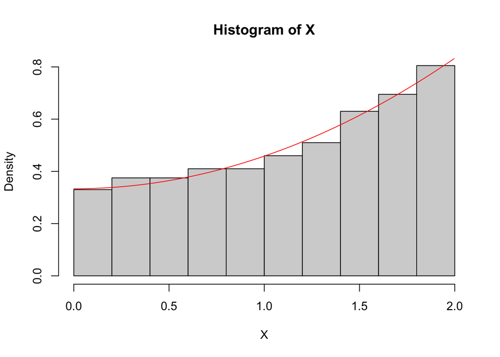

```r
Y <- runif(1750, 0, 2)    # 1750 draws from U(0,2)
c <- 5/3
U <- runif(1750)          # 1750 draws from U(0,1)

accept <- U < (((1/3) + (1/8)*Y^2) / (c * 0.5))

X <- (Y[accept])[1:1000]

hist(X, freq = F, ylim=c(0,0.8))

xx <- seq(0,2,.01)
fx <- (1/3) + (1/8) * xx^2
lines(xx, fx, type = 'l', col='red')
```

Integrating $f_2(t)$ from 0 to x gives me a CDF of: $\frac{x^3}{8}$ Then the inverse of the CDF is: $2 \cdot \sqrt[3]{x}$

```r
# Function to compute inverse of f2(x)

f2x <- function(x) {
  2 * x^(1/3)
}
```

4. 1000 samples

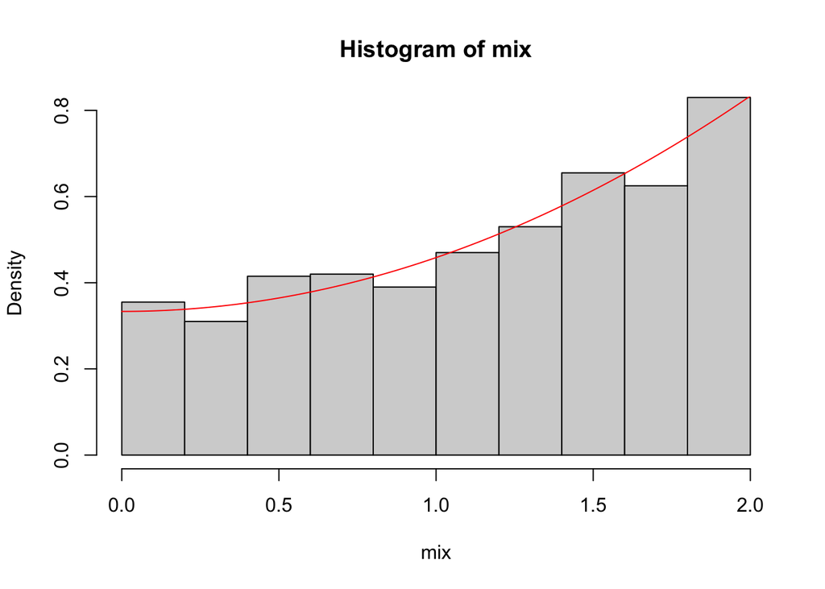

```r
# f1(x): U(0,2)
X_f1x <- runif(1000, 0, 2)

# f2(x): transformation from part (c)
U_f2x <- runif(1000)
X_f2x <- f2x(U_f2x)

u <- runif(1000)
k <- as.integer(u < 2/3)

mix <- (k * X_f1x) + ((1-k) * X_f2x)

# Histogram of Empirical Density
hist(mix, prob=TRUE, ylim=c(0,0.8))

# Theoretical Density Curve
xxd <- seq(0,2,.01)
fxd <- (2/3)*(1/2) + (1/3) * (3/8) * xxd^2
lines(xxd, fxd, type = 'l', col='red')
```

### Question 2

1. 1000 samples from F(3,50) distribution

```r
m <- 3
n <- 50

Y1 <- rowSums(matrix(rnorm(1000*m), 1000, m)^2)    # chi-squared 3df

Y2 <- rowSums(matrix(rnorm(1000*n), 1000, n)^2)    # chi-squared 50df

F_3_50 <- (Y1 / m) / (Y2 / n)
```

2. Importance Sampling Monte Carlo estimate

```r
a <- 2
greater_than_equal_a <- 1*(F_3_50 >= a)
mean(greater_than_equal_a)
```

```
## [1] 0.133
```

```r
# Comparing with R built-in function
1 - pf(2, df1 = 3, df2 = 50)
```

```
## [1] 0.1259421
```

### Question 3

1. Simple MC

```r
X_3a <- runif(1000, 0, sqrt(2))
gX_3a <- (2 / sqrt(pi)) * exp(-(X_3a)^2)
theta_hat_3a <- (sqrt(2) - 0) * mean(gX_3a)
theta_hat_3a
```

```
## [1] 0.9552979
```

```r
# Variance
v = mean((gX_3a - mean(gX_3a))^2) / 1000

# 95% Confidence Interval
c(theta_hat_3a - qnorm(0.975) * sqrt(v), theta_hat_3a + qnorm(0.975) * sqrt(v))
```

```
## [1] 0.9350024 0.9755934
```

2. Stratified MC

```r
strat_mc <- function(total_num, num_strat) {
  xjs <- seq(0, sqrt(2), length.out = num_strat + 1)
  theta = 0

  for (j in 1:num_strat) {
    X <- runif(total_num/num_strat, min=xjs[j], max=xjs[j+1])
    gx <- (2/sqrt(pi)) * exp(-X^2)
    theta = theta + (sqrt(2)/num_strat) * mean(gx)
  }
  return (theta)
}

strat_mc(1000,4)
```

```
## [1] 0.9557538
```

3. Importance Sampling MC

```r
# 1000 standard normal samples
norm_draws <- rnorm(1000)

# Only count samples between -2 and +2
between <- 1*(norm_draws > -2 & norm_draws < 2)

# Mean is our estimate
mean(between)
```

```
## [1] 0.957
```

```r
# Comparing with R built-in function
pnorm(2) - pnorm(-2)
```

```
## [1] 0.9544997
```

4. 100 Replications of (a), (b), and (c)

```r
MC_reps <- matrix(NA, 100, 3)

# Simple MC

for(rep in 1:100) {
  X <- runif(1000, 0, sqrt(2))
  gX <- (2 / sqrt(pi)) * exp(-(X)^2)
  MC_reps[rep,1] <- sqrt(2) * mean(gX)
}

# Stratified MC

for(rep in 1:100) {
  MC_reps[rep,2] <- strat_mc(1000,4)
}

# Importance Sampling MC (Standard Normal Draws)
for(rep in 1:100) {
  norm_draws <- rnorm(1000)
  between <- 1*(norm_draws > -2 & norm_draws < 2)
  MC_reps[rep,3] <- mean(between)
}

round(apply(MC_reps, 2, sd), 6)
```

```
## [1] 0.016198 0.003100 0.006492
```

According to these results, the Simple Monte Carlo estimator is the least efficient, with more than 2x the standard deviation of the standard normal draws and more than 5x the sd of the stratified MC estimator.

### Question 4

1. 1000 samples of Y

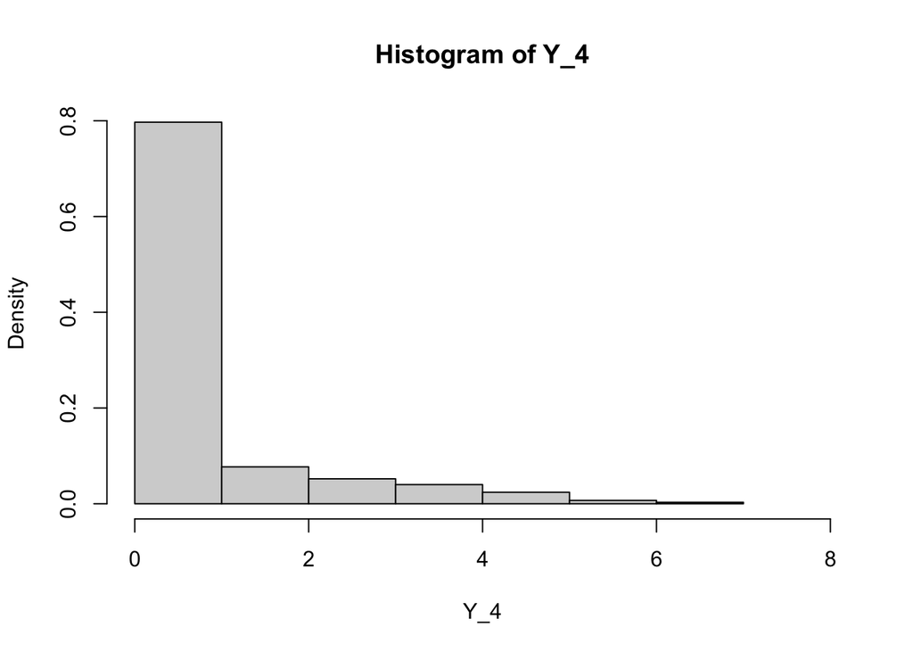

```r
X_4 <- rbinom(1000, size=110, prob=0.9)
Y_4 <- pmax(X_4 - 100, 0)
hist(Y_4, freq=F, xlim=c(0,8), breaks=8)
```

(b) Expected Revenue for n = 110 tickets

```r
mean(100 * 110 - 200 * Y_4)
```

```
## [1] 10846
```

3. Bonus: Optimal number of tickets to maximize revenue

```r
tests <- c()

for(rep in 100:120) {
  X <- rbinom(1000, size=rep, prob=0.9)
  Y <- pmax(X - 100, 0)
  tests[rep-99] <- mean(100 * rep - 200 * Y)
}

# All expected revenues for 100 to 120 tickets sold
tests
```

```
##  [1] 10000.0 10100.0 10199.8 10300.0 10398.8 10495.2 10588.0 10669.2 10750.4
## [10] 10803.2 10829.8 10839.6 10823.0 10857.8 10787.0 10742.8 10699.6 10605.0
## [19] 10526.0 10473.8 10393.4
```

```r
# Maximum revenue amount
max(tests)
```

```
## [1] 10857.8
```

According to these results, the airline should sell 113 tickets to maximize expected revenue.